# Risk Factor Analysis

## Outcome Variable

**Outcome Variable:** sstunted

## Predictor Variables

**Intervention Variable:** feducyrs

**Adjustment Set:**

unadjusted

## Stratifying Variables

The analysis was stratified on these variable(s):

- agecat
- studyid

The following strata were considered:

- agecat: 12 months, studyid: ki0047075b-MAL-ED
- agecat: 12 months, studyid: ki1000304b-SAS-FoodSuppl
- agecat: 12 months, studyid: ki1017093b-PROVIDE
- agecat: 12 months, studyid: ki1017093c-NIH-Crypto
- agecat: 12 months, studyid: ki1066203-TanzaniaChild2
- agecat: 12 months, studyid: ki1113344-GMS-Nepal
- agecat: 12 months, studyid: ki1126311-ZVITAMBO
- agecat: 12 months, studyid: ki1135781-COHORTS
- agecat: 12 months, studyid: ki1148112-LCNI-5
- agecat: 18 months, studyid: ki0047075b-MAL-ED
- agecat: 18 months, studyid: ki1000304b-SAS-FoodSuppl
- agecat: 18 months, studyid: ki1017093b-PROVIDE
- agecat: 18 months, studyid: ki1017093c-NIH-Crypto
- agecat: 18 months, studyid: ki1066203-TanzaniaChild2
- agecat: 18 months, studyid: ki1113344-GMS-Nepal
- agecat: 18 months, studyid: ki1126311-ZVITAMBO
- agecat: 18 months, studyid: ki1135781-COHORTS
- agecat: 18 months, studyid: ki1148112-LCNI-5
- agecat: 24 months, studyid: ki0047075b-MAL-ED
- agecat: 24 months, studyid: ki1017093b-PROVIDE
- agecat: 24 months, studyid: ki1017093c-NIH-Crypto
- agecat: 24 months, studyid: ki1066203-TanzaniaChild2
- agecat: 24 months, studyid: ki1113344-GMS-Nepal
- agecat: 24 months, studyid: ki1126311-ZVITAMBO
- agecat: 24 months, studyid: ki1135781-COHORTS
- agecat: 24 months, studyid: ki1148112-LCNI-5
- agecat: 3 months, studyid: ki0047075b-MAL-ED
- agecat: 3 months, studyid: ki1000304b-SAS-FoodSuppl
- agecat: 3 months, studyid: ki1017093b-PROVIDE
- agecat: 3 months, studyid: ki1017093c-NIH-Crypto
- agecat: 3 months, studyid: ki1066203-TanzaniaChild2
- agecat: 3 months, studyid: ki1113344-GMS-Nepal
- agecat: 3 months, studyid: ki1126311-ZVITAMBO
- agecat: 3 months, studyid: ki1135781-COHORTS
- agecat: 6 months, studyid: ki0047075b-MAL-ED
- agecat: 6 months, studyid: ki1000304b-SAS-FoodSuppl
- agecat: 6 months, studyid: ki1017093b-PROVIDE
- agecat: 6 months, studyid: ki1017093c-NIH-Crypto
- agecat: 6 months, studyid: ki1066203-TanzaniaChild2
- agecat: 6 months, studyid: ki1113344-GMS-Nepal
- agecat: 6 months, studyid: ki1126311-ZVITAMBO
- agecat: 6 months, studyid: ki1135781-COHORTS
- agecat: 6 months, studyid: ki1148112-LCNI-5
- agecat: 9 months, studyid: ki0047075b-MAL-ED
- agecat: 9 months, studyid: ki1000304b-SAS-FoodSuppl
- agecat: 9 months, studyid: ki1017093b-PROVIDE
- agecat: 9 months, studyid: ki1017093c-NIH-Crypto
- agecat: 9 months, studyid: ki1066203-TanzaniaChild2
- agecat: 9 months, studyid: ki1113344-GMS-Nepal
- agecat: 9 months, studyid: ki1126311-ZVITAMBO
- agecat: 9 months, studyid: ki1135781-COHORTS
- agecat: 9 months, studyid: ki1148112-LCNI-5
- agecat: Birth, studyid: ki0047075b-MAL-ED
- agecat: Birth, studyid: ki1017093c-NIH-Crypto
- agecat: Birth, studyid: ki1126311-ZVITAMBO
- agecat: Birth, studyid: ki1135781-COHORTS

### Dropped Strata

Some strata were dropped due to rare outcomes:

- agecat: Birth, studyid: ki0047075b-MAL-ED
- agecat: Birth, studyid: ki1017093c-NIH-Crypto
- agecat: Birth, studyid: ki1126311-ZVITAMBO
- agecat: Birth, studyid: ki1135781-COHORTS
- agecat: 3 months, studyid: ki0047075b-MAL-ED
- agecat: 3 months, studyid: ki1000304b-SAS-FoodSuppl
- agecat: 3 months, studyid: ki1017093b-PROVIDE
- agecat: 3 months, studyid: ki1017093c-NIH-Crypto
- agecat: 3 months, studyid: ki1066203-TanzaniaChild2
- agecat: 3 months, studyid: ki1113344-GMS-Nepal
- agecat: 3 months, studyid: ki1126311-ZVITAMBO
- agecat: 6 months, studyid: ki0047075b-MAL-ED
- agecat: 6 months, studyid: ki1000304b-SAS-FoodSuppl
- agecat: 6 months, studyid: ki1017093b-PROVIDE
- agecat: 6 months, studyid: ki1017093c-NIH-Crypto
- agecat: 6 months, studyid: ki1066203-TanzaniaChild2
- agecat: 6 months, studyid: ki1113344-GMS-Nepal
- agecat: 6 months, studyid: ki1126311-ZVITAMBO
- agecat: 6 months, studyid: ki1148112-LCNI-5
- agecat: 9 months, studyid: ki0047075b-MAL-ED
- agecat: 9 months, studyid: ki1000304b-SAS-FoodSuppl
- agecat: 9 months, studyid: ki1017093b-PROVIDE
- agecat: 9 months, studyid: ki1066203-TanzaniaChild2
- agecat: 9 months, studyid: ki1113344-GMS-Nepal
- agecat: 9 months, studyid: ki1126311-ZVITAMBO
- agecat: 9 months, studyid: ki1148112-LCNI-5
- agecat: 12 months, studyid: ki0047075b-MAL-ED
- agecat: 12 months, studyid: ki1017093b-PROVIDE
- agecat: 12 months, studyid: ki1066203-TanzaniaChild2
- agecat: 12 months, studyid: ki1113344-GMS-Nepal
- agecat: 12 months, studyid: ki1126311-ZVITAMBO
- agecat: 12 months, studyid: ki1148112-LCNI-5
- agecat: 18 months, studyid: ki0047075b-MAL-ED
- agecat: 18 months, studyid: ki1000304b-SAS-FoodSuppl
- agecat: 18 months, studyid: ki1017093b-PROVIDE
- agecat: 18 months, studyid: ki1066203-TanzaniaChild2
- agecat: 18 months, studyid: ki1126311-ZVITAMBO
- agecat: 18 months, studyid: ki1148112-LCNI-5
- agecat: 24 months, studyid: ki1017093b-PROVIDE
- agecat: 24 months, studyid: ki1066203-TanzaniaChild2
- agecat: 24 months, studyid: ki1126311-ZVITAMBO
- agecat: 24 months, studyid: ki1148112-LCNI-5

## Methods Detail

We’re interested in the causal parameters $E[Y_a]$ for all values of $a \in \mathcal{A}$. These parameters represent the mean outcome if, possibly contrary to fact, we intervened to set all units to have $A=a$. Under the randomization and positivity assumptions, these are identified by the statistical parameters $\psi_a=E_W[E_{Y|A,W}(Y|A=a,W)]$. In addition, we’re interested in the mean of $Y$, $E[Y]$ under no intervention (the observed mean). We will estimate these parameters by using SuperLearner to fit the relevant likelihood factors – $E_{Y|A,W}(Y|A=a,W)$ and $p(A=a|W)$, and then updating our likelihood fit using a joint TMLE.

For unadjusted analyses ($W=\{\}$), initial likelihoods were estimated using Lrnr_glm to estimate the simple $E(Y|A)$ and Lrnr_mean to estimate $p(A)$. For adjusted analyses, a small library containing Lrnr_glmnet, Lrnr_xgboost, and Lrnr_mean was used.

Having estimated these parameters, we will then use the delta method to estimate relative risks and attributable risks relative to a prespecified baseline level of $A$.

# Results Detail

## Results Plots

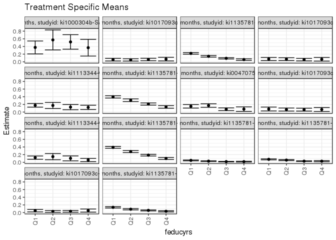

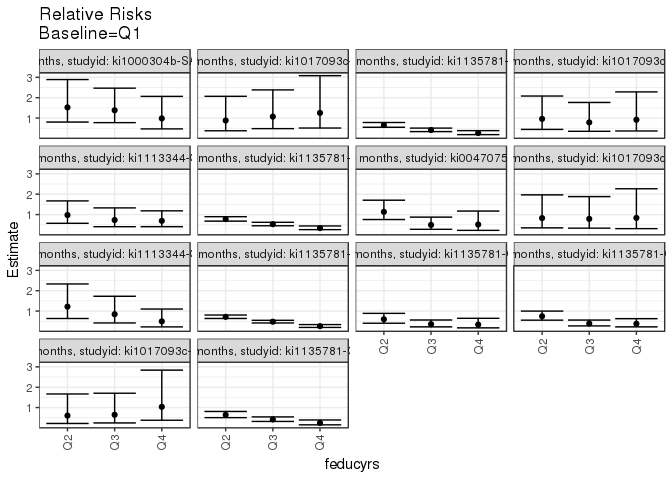

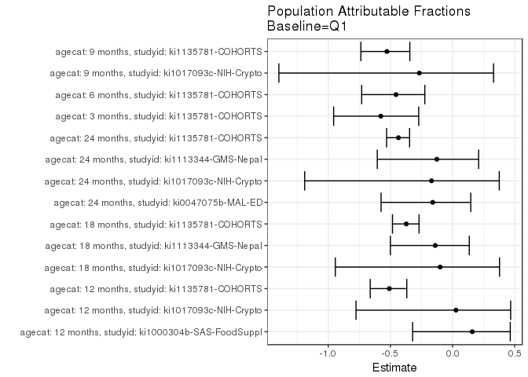

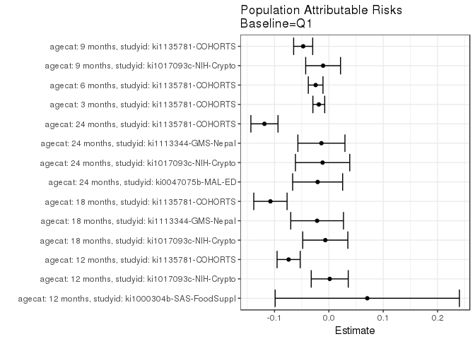

## Data Summary

| agecat | studyid | A | n | nA | nAY0 | nAY1 |
| --- | --- | --- | --- | --- | --- | --- |
| Birth | ki0047075b-MAL-ED | Q1 | 762 | 225 | 217 | 8 |
| Birth | ki0047075b-MAL-ED | Q2 | 762 | 226 | 216 | 10 |
| Birth | ki0047075b-MAL-ED | Q3 | 762 | 229 | 226 | 3 |
| Birth | ki0047075b-MAL-ED | Q4 | 762 | 82 | 78 | 4 |
| Birth | ki1000304b-SAS-FoodSuppl | Q1 | 0 | 0 | 0 | 0 |
| Birth | ki1000304b-SAS-FoodSuppl | Q2 | 0 | 0 | 0 | 0 |
| Birth | ki1000304b-SAS-FoodSuppl | Q3 | 0 | 0 | 0 | 0 |
| Birth | ki1000304b-SAS-FoodSuppl | Q4 | 0 | 0 | 0 | 0 |
| Birth | ki1017093b-PROVIDE | Q1 | 0 | 0 | 0 | 0 |
| Birth | ki1017093b-PROVIDE | Q2 | 0 | 0 | 0 | 0 |
| Birth | ki1017093b-PROVIDE | Q3 | 0 | 0 | 0 | 0 |
| Birth | ki1017093b-PROVIDE | Q4 | 0 | 0 | 0 | 0 |
| Birth | ki1017093c-NIH-Crypto | Q1 | 27 | 7 | 7 | 0 |
| Birth | ki1017093c-NIH-Crypto | Q2 | 27 | 9 | 9 | 0 |
| Birth | ki1017093c-NIH-Crypto | Q3 | 27 | 8 | 7 | 1 |
| Birth | ki1017093c-NIH-Crypto | Q4 | 27 | 3 | 3 | 0 |
| Birth | ki1066203-TanzaniaChild2 | Q1 | 0 | 0 | 0 | 0 |
| Birth | ki1066203-TanzaniaChild2 | Q2 | 0 | 0 | 0 | 0 |
| Birth | ki1066203-TanzaniaChild2 | Q3 | 0 | 0 | 0 | 0 |
| Birth | ki1066203-TanzaniaChild2 | Q4 | 0 | 0 | 0 | 0 |
| Birth | ki1113344-GMS-Nepal | Q1 | 0 | 0 | 0 | 0 |
| Birth | ki1113344-GMS-Nepal | Q2 | 0 | 0 | 0 | 0 |
| Birth | ki1113344-GMS-Nepal | Q3 | 0 | 0 | 0 | 0 |
| Birth | ki1113344-GMS-Nepal | Q4 | 0 | 0 | 0 | 0 |
| Birth | ki1126311-ZVITAMBO | Q1 | 3373 | 15 | 13 | 2 |
| Birth | ki1126311-ZVITAMBO | Q2 | 3373 | 23 | 23 | 0 |
| Birth | ki1126311-ZVITAMBO | Q3 | 3373 | 441 | 421 | 20 |
| Birth | ki1126311-ZVITAMBO | Q4 | 3373 | 2894 | 2807 | 87 |
| Birth | ki1135781-COHORTS | Q1 | 4608 | 1546 | 1518 | 28 |
| Birth | ki1135781-COHORTS | Q2 | 4608 | 1128 | 1104 | 24 |

[output cut: 222 more lines]

## Results Table

### Parameter: TSM

| agecat | studyid | intervention_level | baseline_level | estimate | ci_lower | ci_upper |
| --- | --- | --- | --- | --- | --- | --- |
| 3 months | ki1135781-COHORTS | Q1 | NA | 0.0505762 | 0.0397080 | 0.0614444 |
| 3 months | ki1135781-COHORTS | Q2 | NA | 0.0302222 | 0.0202172 | 0.0402273 |
| 3 months | ki1135781-COHORTS | Q3 | NA | 0.0179547 | 0.0106823 | 0.0252271 |
| 3 months | ki1135781-COHORTS | Q4 | NA | 0.0170068 | 0.0065549 | 0.0274587 |
| 6 months | ki1135781-COHORTS | Q1 | NA | 0.0777851 | 0.0643057 | 0.0912645 |
| 6 months | ki1135781-COHORTS | Q2 | NA | 0.0577982 | 0.0439429 | 0.0716534 |
| 6 months | ki1135781-COHORTS | Q3 | NA | 0.0302288 | 0.0206358 | 0.0398217 |
| 6 months | ki1135781-COHORTS | Q4 | NA | 0.0291971 | 0.0150996 | 0.0432946 |
| 9 months | ki1017093c-NIH-Crypto | Q1 | NA | 0.0502793 | 0.0182445 | 0.0823141 |
| 9 months | ki1017093c-NIH-Crypto | Q2 | NA | 0.0304569 | 0.0064437 | 0.0544700 |
| 9 months | ki1017093c-NIH-Crypto | Q3 | NA | 0.0325581 | 0.0088182 | 0.0562980 |
| 9 months | ki1017093c-NIH-Crypto | Q4 | NA | 0.0521739 | 0.0115017 | 0.0928461 |
| 9 months | ki1135781-COHORTS | Q1 | NA | 0.1367925 | 0.1193072 | 0.1542777 |
| 9 months | ki1135781-COHORTS | Q2 | NA | 0.0876190 | 0.0705153 | 0.1047228 |
| 9 months | ki1135781-COHORTS | Q3 | NA | 0.0570213 | 0.0437611 | 0.0702815 |
| 9 months | ki1135781-COHORTS | Q4 | NA | 0.0335196 | 0.0182945 | 0.0487446 |
| 12 months | ki1000304b-SAS-FoodSuppl | Q1 | NA | 0.3750000 | 0.2063439 | 0.5436561 |
| 12 months | ki1000304b-SAS-FoodSuppl | Q2 | NA | 0.5714286 | 0.3107833 | 0.8320739 |
| 12 months | ki1000304b-SAS-FoodSuppl | Q3 | NA | 0.5185185 | 0.3290176 | 0.7080195 |
| 12 months | ki1000304b-SAS-FoodSuppl | Q4 | NA | 0.3684211 | 0.1503337 | 0.5865084 |
| 12 months | ki1017093c-NIH-Crypto | Q1 | NA | 0.0564972 | 0.0224599 | 0.0905344 |
| 12 months | ki1017093c-NIH-Crypto | Q2 | NA | 0.0497512 | 0.0196712 | 0.0798313 |
| 12 months | ki1017093c-NIH-Crypto | Q3 | NA | 0.0604651 | 0.0285831 | 0.0923471 |
| 12 months | ki1017093c-NIH-Crypto | Q4 | NA | 0.0707965 | 0.0234729 | 0.1181201 |
| 12 months | ki1135781-COHORTS | Q1 | NA | 0.2196453 | 0.1984499 | 0.2408407 |
| 12 months | ki1135781-COHORTS | Q2 | NA | 0.1437008 | 0.1221285 | 0.1652731 |
| 12 months | ki1135781-COHORTS | Q3 | NA | 0.0905058 | 0.0737534 | 0.1072582 |
| 12 months | ki1135781-COHORTS | Q4 | NA | 0.0585938 | 0.0382477 | 0.0789398 |
| 18 months | ki1017093c-NIH-Crypto | Q1 | NA | 0.0728477 | 0.0313632 | 0.1143322 |
| 18 months | ki1017093c-NIH-Crypto | Q2 | NA | 0.0698925 | 0.0332220 | 0.1065629 |
| 18 months | ki1017093c-NIH-Crypto | Q3 | NA | 0.0572917 | 0.0243933 | 0.0901901 |
| 18 months | ki1017093c-NIH-Crypto | Q4 | NA | 0.0666667 | 0.0189172 | 0.1144162 |
| 18 months | ki1113344-GMS-Nepal | Q1 | NA | 0.1764706 | 0.1279941 | 0.2249471 |
| 18 months | ki1113344-GMS-Nepal | Q2 | NA | 0.1724138 | 0.0929669 | 0.2518607 |
| 18 months | ki1113344-GMS-Nepal | Q3 | NA | 0.1290323 | 0.0608372 | 0.1972273 |
| 18 months | ki1113344-GMS-Nepal | Q4 | NA | 0.1221374 | 0.0660137 | 0.1782611 |
| 18 months | ki1135781-COHORTS | Q1 | NA | 0.3961694 | 0.3657276 | 0.4266111 |
| 18 months | ki1135781-COHORTS | Q2 | NA | 0.3085443 | 0.2725272 | 0.3445614 |
| 18 months | ki1135781-COHORTS | Q3 | NA | 0.2093960 | 0.1801738 | 0.2386181 |
| 18 months | ki1135781-COHORTS | Q4 | NA | 0.1336761 | 0.0998526 | 0.1674996 |
| 24 months | ki0047075b-MAL-ED | Q1 | NA | 0.1502146 | 0.1043093 | 0.1961198 |
| 24 months | ki0047075b-MAL-ED | Q2 | NA | 0.1705426 | 0.1246193 | 0.2164659 |
| 24 months | ki0047075b-MAL-ED | Q3 | NA | 0.0738916 | 0.0378827 | 0.1099005 |
| 24 months | ki0047075b-MAL-ED | Q4 | NA | 0.0769231 | 0.0177493 | 0.1360969 |
| 24 months | ki1017093c-NIH-Crypto | Q1 | NA | 0.0796460 | 0.0296781 | 0.1296139 |
| 24 months | ki1017093c-NIH-Crypto | Q2 | NA | 0.0657895 | 0.0263392 | 0.1052397 |
| 24 months | ki1017093c-NIH-Crypto | Q3 | NA | 0.0628931 | 0.0251212 | 0.1006649 |
| 24 months | ki1017093c-NIH-Crypto | Q4 | NA | 0.0666667 | 0.0150818 | 0.1182516 |
| 24 months | ki1113344-GMS-Nepal | Q1 | NA | 0.1221719 | 0.0789525 | 0.1653914 |
| 24 months | ki1113344-GMS-Nepal | Q2 | NA | 0.1486486 | 0.0675145 | 0.2297828 |
| 24 months | ki1113344-GMS-Nepal | Q3 | NA | 0.1034483 | 0.0393901 | 0.1675064 |
| 24 months | ki1113344-GMS-Nepal | Q4 | NA | 0.0603448 | 0.0169678 | 0.1037219 |
| 24 months | ki1135781-COHORTS | Q1 | NA | 0.3907507 | 0.3659900 | 0.4155114 |
| 24 months | ki1135781-COHORTS | Q2 | NA | 0.2798434 | 0.2523173 | 0.3073696 |
| 24 months | ki1135781-COHORTS | Q3 | NA | 0.1867365 | 0.1641713 | 0.2093016 |
| 24 months | ki1135781-COHORTS | Q4 | NA | 0.1007905 | 0.0745565 | 0.1270246 |

### Parameter: E(Y)

| agecat | studyid | intervention_level | baseline_level | estimate | ci_lower | ci_upper |
| --- | --- | --- | --- | --- | --- | --- |
| 3 months | ki1135781-COHORTS | NA | NA | 0.0320457 | 0.0316313 | 0.0324600 |
| 6 months | ki1135781-COHORTS | NA | NA | 0.0534369 | 0.0528196 | 0.0540541 |
| 9 months | ki1017093c-NIH-Crypto | NA | NA | 0.0396601 | 0.0389478 | 0.0403723 |
| 9 months | ki1135781-COHORTS | NA | NA | 0.0894960 | 0.0883423 | 0.0906497 |
| 12 months | ki1000304b-SAS-FoodSuppl | NA | NA | 0.4456522 | 0.4285438 | 0.4627605 |
| 12 months | ki1017093c-NIH-Crypto | NA | NA | 0.0580737 | 0.0575623 | 0.0585850 |
| 12 months | ki1135781-COHORTS | NA | NA | 0.1455957 | 0.1437329 | 0.1474586 |
| 18 months | ki1017093c-NIH-Crypto | NA | NA | 0.0662461 | 0.0657621 | 0.0667300 |
| 18 months | ki1113344-GMS-Nepal | NA | NA | 0.1548270 | 0.1527426 | 0.1569114 |
| 18 months | ki1135781-COHORTS | NA | NA | 0.2886149 | 0.2850088 | 0.2922210 |
| 24 months | ki0047075b-MAL-ED | NA | NA | 0.1295337 | 0.1265516 | 0.1325158 |
| 24 months | ki1017093c-NIH-Crypto | NA | NA | 0.0680934 | 0.0675486 | 0.0686382 |
| 24 months | ki1113344-GMS-Nepal | NA | NA | 0.1084337 | 0.1058449 | 0.1110225 |
| 24 months | ki1135781-COHORTS | NA | NA | 0.2722036 | 0.2690730 | 0.2753341 |

### Parameter: RR

| agecat | studyid | intervention_level | baseline_level | estimate | ci_lower | ci_upper |
| --- | --- | --- | --- | --- | --- | --- |
| 3 months | ki1135781-COHORTS | Q2 | Q1 | 0.5975584 | 0.4026930 | 0.8867202 |
| 3 months | ki1135781-COHORTS | Q3 | Q1 | 0.3550035 | 0.2244414 | 0.5615162 |
| 3 months | ki1135781-COHORTS | Q4 | Q1 | 0.3362611 | 0.1753586 | 0.6448017 |
| 6 months | ki1135781-COHORTS | Q2 | Q1 | 0.7430493 | 0.5527849 | 0.9988012 |
| 6 months | ki1135781-COHORTS | Q3 | Q1 | 0.3886189 | 0.2707033 | 0.5578973 |
| 6 months | ki1135781-COHORTS | Q4 | Q1 | 0.3753557 | 0.2247254 | 0.6269514 |
| 9 months | ki1017093c-NIH-Crypto | Q2 | Q1 | 0.6057530 | 0.2198142 | 1.6693039 |
| 9 months | ki1017093c-NIH-Crypto | Q3 | Q1 | 0.6475452 | 0.2458906 | 1.7052903 |
| 9 months | ki1017093c-NIH-Crypto | Q4 | Q1 | 1.0376812 | 0.3791551 | 2.8399515 |
| 9 months | ki1135781-COHORTS | Q2 | Q1 | 0.6405255 | 0.5072258 | 0.8088565 |
| 9 months | ki1135781-COHORTS | Q3 | Q1 | 0.4168452 | 0.3196902 | 0.5435260 |
| 9 months | ki1135781-COHORTS | Q4 | Q1 | 0.2450395 | 0.1528662 | 0.3927901 |
| 12 months | ki1000304b-SAS-FoodSuppl | Q2 | Q1 | 1.5238095 | 0.8030362 | 2.8915201 |
| 12 months | ki1000304b-SAS-FoodSuppl | Q3 | Q1 | 1.3827160 | 0.7745544 | 2.4683917 |
| 12 months | ki1000304b-SAS-FoodSuppl | Q4 | Q1 | 0.9824561 | 0.4671407 | 2.0662301 |
| 12 months | ki1017093c-NIH-Crypto | Q2 | Q1 | 0.8805970 | 0.3750551 | 2.0675660 |
| 12 months | ki1017093c-NIH-Crypto | Q3 | Q1 | 1.0702326 | 0.4805921 | 2.3833054 |
| 12 months | ki1017093c-NIH-Crypto | Q4 | Q1 | 1.2530973 | 0.5095345 | 3.0817400 |
| 12 months | ki1135781-COHORTS | Q2 | Q1 | 0.6542402 | 0.5473099 | 0.7820620 |
| 12 months | ki1135781-COHORTS | Q3 | Q1 | 0.4120542 | 0.3344253 | 0.5077029 |
| 12 months | ki1135781-COHORTS | Q4 | Q1 | 0.2667653 | 0.1860417 | 0.3825149 |
| 18 months | ki1017093c-NIH-Crypto | Q2 | Q1 | 0.9594330 | 0.4423147 | 2.0811241 |
| 18 months | ki1017093c-NIH-Crypto | Q3 | Q1 | 0.7864583 | 0.3503098 | 1.7656277 |
| 18 months | ki1017093c-NIH-Crypto | Q4 | Q1 | 0.9151515 | 0.3665187 | 2.2850195 |
| 18 months | ki1113344-GMS-Nepal | Q2 | Q1 | 0.9770115 | 0.5713707 | 1.6706341 |
| 18 months | ki1113344-GMS-Nepal | Q3 | Q1 | 0.7311828 | 0.4030359 | 1.3265030 |
| 18 months | ki1113344-GMS-Nepal | Q4 | Q1 | 0.6921120 | 0.4052022 | 1.1821725 |
| 18 months | ki1135781-COHORTS | Q2 | Q1 | 0.7788192 | 0.6772402 | 0.8956340 |
| 18 months | ki1135781-COHORTS | Q3 | Q1 | 0.5285517 | 0.4507126 | 0.6198337 |
| 18 months | ki1135781-COHORTS | Q4 | Q1 | 0.3374216 | 0.2590178 | 0.4395579 |
| 24 months | ki0047075b-MAL-ED | Q2 | Q1 | 1.1353267 | 0.7554903 | 1.7061326 |
| 24 months | ki0047075b-MAL-ED | Q3 | Q1 | 0.4919071 | 0.2767392 | 0.8743704 |
| 24 months | ki0047075b-MAL-ED | Q4 | Q1 | 0.5120879 | 0.2238012 | 1.1717273 |
| 24 months | ki1017093c-NIH-Crypto | Q2 | Q1 | 0.8260234 | 0.3468069 | 1.9674192 |
| 24 months | ki1017093c-NIH-Crypto | Q3 | Q1 | 0.7896576 | 0.3313259 | 1.8820112 |
| 24 months | ki1017093c-NIH-Crypto | Q4 | Q1 | 0.8370370 | 0.3091150 | 2.2665704 |
| 24 months | ki1113344-GMS-Nepal | Q2 | Q1 | 1.2167167 | 0.6349105 | 2.3316664 |
| 24 months | ki1113344-GMS-Nepal | Q3 | Q1 | 0.8467433 | 0.4149853 | 1.7277100 |
| 24 months | ki1113344-GMS-Nepal | Q4 | Q1 | 0.4939336 | 0.2216828 | 1.1005380 |
| 24 months | ki1135781-COHORTS | Q2 | Q1 | 0.7161688 | 0.6370888 | 0.8050648 |
| 24 months | ki1135781-COHORTS | Q3 | Q1 | 0.4778916 | 0.4169381 | 0.5477562 |
| 24 months | ki1135781-COHORTS | Q4 | Q1 | 0.2579407 | 0.1973235 | 0.3371794 |

### Parameter: PAR

| agecat | studyid | intervention_level | baseline_level | estimate | ci_lower | ci_upper |
| --- | --- | --- | --- | --- | --- | --- |
| 3 months | ki1135781-COHORTS | Q1 | NA | -0.0185305 | -0.0294066 | -0.0076544 |
| 6 months | ki1135781-COHORTS | Q1 | NA | -0.0243482 | -0.0378417 | -0.0108548 |
| 9 months | ki1017093c-NIH-Crypto | Q1 | NA | -0.0106193 | -0.0426620 | 0.0214234 |
| 9 months | ki1135781-COHORTS | Q1 | NA | -0.0472965 | -0.0648197 | -0.0297732 |
| 12 months | ki1000304b-SAS-FoodSuppl | Q1 | NA | 0.0706522 | -0.0988694 | 0.2401737 |
| 12 months | ki1017093c-NIH-Crypto | Q1 | NA | 0.0015765 | -0.0324646 | 0.0356176 |
| 12 months | ki1135781-COHORTS | Q1 | NA | -0.0740496 | -0.0953266 | -0.0527725 |
| 18 months | ki1017093c-NIH-Crypto | Q1 | NA | -0.0066016 | -0.0480889 | 0.0348857 |
| 18 months | ki1113344-GMS-Nepal | Q1 | NA | -0.0216436 | -0.0701649 | 0.0268777 |
| 18 months | ki1135781-COHORTS | Q1 | NA | -0.1075544 | -0.1382090 | -0.0768999 |
| 24 months | ki0047075b-MAL-ED | Q1 | NA | -0.0206809 | -0.0666829 | 0.0253211 |
| 24 months | ki1017093c-NIH-Crypto | Q1 | NA | -0.0115526 | -0.0615235 | 0.0384183 |
| 24 months | ki1113344-GMS-Nepal | Q1 | NA | -0.0137382 | -0.0570351 | 0.0295587 |
| 24 months | ki1135781-COHORTS | Q1 | NA | -0.1185471 | -0.1435049 | -0.0935893 |

### Parameter: PAF

| agecat | studyid | intervention_level | baseline_level | estimate | ci_lower | ci_upper |
| --- | --- | --- | --- | --- | --- | --- |
| 3 months | ki1135781-COHORTS | Q1 | NA | -0.5782541 | -0.9573586 | -0.2725752 |
| 6 months | ki1135781-COHORTS | Q1 | NA | -0.4556451 | -0.7317344 | -0.2235726 |
| 9 months | ki1017093c-NIH-Crypto | Q1 | NA | -0.2677574 | -1.3980098 | 0.3297739 |
| 9 months | ki1135781-COHORTS | Q1 | NA | -0.5284757 | -0.7380126 | -0.3442008 |
| 12 months | ki1000304b-SAS-FoodSuppl | Q1 | NA | 0.1585366 | -0.3215063 | 0.4642018 |
| 12 months | ki1017093c-NIH-Crypto | Q1 | NA | 0.0271462 | -0.7771338 | 0.4674321 |
| 12 months | ki1135781-COHORTS | Q1 | NA | -0.5085971 | -0.6628331 | -0.3686673 |
| 18 months | ki1017093c-NIH-Crypto | Q1 | NA | -0.0996531 | -0.9435391 | 0.3778170 |
| 18 months | ki1113344-GMS-Nepal | Q1 | NA | -0.1397924 | -0.5006164 | 0.1342713 |
| 18 months | ki1135781-COHORTS | Q1 | NA | -0.3726571 | -0.4837872 | -0.2698503 |
| 24 months | ki0047075b-MAL-ED | Q1 | NA | -0.1596567 | -0.5755236 | 0.1464403 |
| 24 months | ki1017093c-NIH-Crypto | Q1 | NA | -0.1696587 | -1.1905177 | 0.3754438 |
| 24 months | ki1113344-GMS-Nepal | Q1 | NA | -0.1266968 | -0.6061722 | 0.2096453 |
| 24 months | ki1135781-COHORTS | Q1 | NA | -0.4355091 | -0.5310010 | -0.3459732 |